# Francsico Antonio Cuellar Sifuentes #598303

Lo datos para trabajar se recuperaron de La Organización Mundial de la Salud (OMS), a través de su Observatorio Mundial de la Salud (GHO), se recopiló y monitoreo información sobre el estado de salud y otros factores asociados en todos los países. Sus conjuntos de datos están disponibles públicamente para el análisis de información relacionada con la salud. Para recopilar los datos se utilizó un conjunto de datos sobre la esperanza de vida y factores de salud de 193 países, obtenido del repositorio de la OMS, complementado con datos económicos extraídos del sitio web de las Naciones Unidas.

Se seleccionaron únicamente aquellos factores críticos más representativos dentro de las categorías de salud. Durante los últimos 15 años, se ha observado avance en el sector sanitario importante, lo que ha mejorado las tasas de mortalidad, especialmente en los países en desarrollo, en comparación con las tres décadas anteriores. Por ello, el análisis se centra en el período 2000-2015 para 193 países. Los distintos archivos de datos fueron combinados en un único conjunto para facilitar el análisis.

Respecto al tratamiento de los datos previo a este proyecto, una inspección visual inicial reveló la presencia de valores faltantes. Dado que los datos provenían de la OMS, no se detectaron errores evidentes. Para el tratamiento de los valores ausentes, se utilizó el software R con la función Missmap, que evidenció que la mayoría de los datos ausentes correspondían a población, hepatitis B y PIB. Estos valores faltantes se concentraban en países menos conocidos, como Vanuatu, Tonga, Togo y Cabo Verde, lo que dificultó la recopilación completa de la información. Por ello, se decidió excluir estos países del conjunto de datos final.

El archivo consolidado contiene 22 columnas y 2938 filas, lo que representa un total de 20 variables predictoras. Estas variables se agruparon en cuatro grandes categorías: factores relacionados con la inmunización, factores de mortalidad, factores económicos y factores sociales.

En el proyecto que se desarrollará a continuación se buscará identificar si, a partir de información relacionada con factores de salud y economía, es posible predecir la esperanza de vida de una población. Además, caracterizar la relación entre la tasa de mortalidad adulta y la esperanza de vida, analizando su impacto en diferentes países y periodos de tiempo.

1. Comenzaremos importa los datos al ambiente de trabajo. imprimiremos características de la base de datos, imprimiendo en consola y graficando información relevante como: cantidad de observaciones, cantidad de variables, tipo de variables, nombre de variables, información general del DataFrames, mostrar estadísticas descriptivas.

```python
import pandas as pd

# Cargar el conjunto de datos
df = pd.read_csv('Life_Expectancy_Data.csv')

# Mostrar las primeras filas del conjunto de datos
df.head()

# Obtener información general del DataFrame
df.info()

# Mostrar estadísticas descriptivas
df.describe()

# Verificar los nombres de las columnas en el DataFrame
print(df.columns)
```

```
<class 'pandas.core.frame.DataFrame'>
RangeIndex: 2938 entries, 0 to 2937
Data columns (total 22 columns):
 #   Column                           Non-Null Count  Dtype
---  ------                           --------------  -----
 0   Country                          2938 non-null   object
 1   Year                             2938 non-null   int64
 2   Status                           2938 non-null   object
 3   Life expectancy                  2928 non-null   float64
 4   Adult Mortality                  2928 non-null   float64
 5   infant deaths                    2938 non-null   int64
 6   Alcohol                          2744 non-null   float64
 7   percentage expenditure           2938 non-null   float64
 8   Hepatitis B                      2385 non-null   float64
 9   Measles                          2938 non-null   int64
 10   BMI                             2904 non-null   float64
 11  under-five deaths                2938 non-null   int64
 12  Polio                            2919 non-null   float64
 13  Total expenditure                2712 non-null   float64
 14  Diphtheria                       2919 non-null   float64
 15   HIV/AIDS                        2938 non-null   float64
 16  GDP                              2490 non-null   float64
 17  Population                       2286 non-null   float64
 18   thinness  1-19 years            2904 non-null   float64
 19   thinness 5-9 years              2904 non-null   float64
 20  Income composition of resources  2771 non-null   float64
 21  Schooling                        2775 non-null   float64
dtypes: float64(16), int64(4), object(2)
memory usage: 505.1+ KB
Index(['Country', 'Year', 'Status', 'Life expectancy ', 'Adult Mortality',
       'infant deaths', 'Alcohol', 'percentage expenditure', 'Hepatitis B',
       'Measles ', ' BMI ', 'under-five deaths ', 'Polio', 'Total expenditure',
       'Diphtheria ', ' HIV/AIDS', 'GDP', 'Population',
       ' thinness  1-19 years', ' thinness 5-9 years',
       'Income composition of resources', 'Schooling'],
      dtype='object')
```

La información que tenemos a la mano claramente debe ser procesada y limpiada, sin embargo por la naturaleza de los datos es fácil identificar una relación, que necesitan comprobación, pero se puede suponer que mientras la calidad de vida aumente la esperanza de vida también, y es ahí donde podemos encontrar una relación lineal, sin embargo esta suposición viene con cierto sesgo que incluso puede ser refutado con otras tendencias que pueden seguir los datos (tendencias no lineales), es necesario seguir a analizando e investigando dentro de los datos.

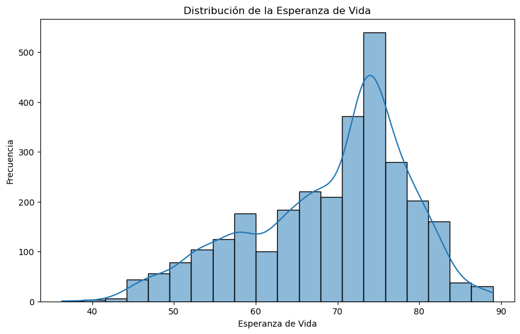

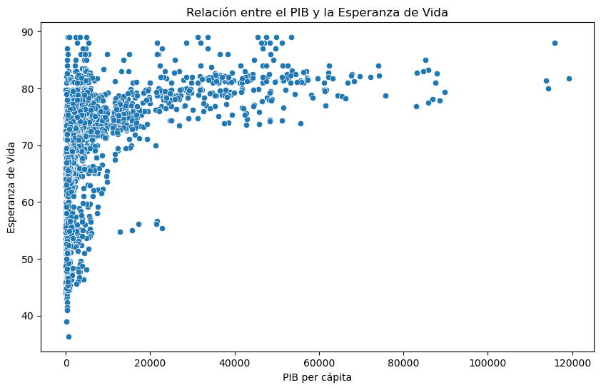

```python
import matplotlib.pyplot as plt
import seaborn as sns

# Graficar la distribución de la esperanza de vida
plt.figure(figsize=(10, 6))
sns.histplot(df['Life expectancy '], bins=20, kde=True)
plt.title('Distribución de la Esperanza de Vida')
plt.xlabel('Esperanza de Vida')
plt.ylabel('Frecuencia')
plt.show()

# Graficar la relación entre el PIB y la esperanza de vida
plt.figure(figsize=(10, 6))
sns.scatterplot(data=df, x='GDP', y='Life expectancy ')
plt.title('Relación entre el PIB y la Esperanza de Vida')
plt.xlabel('PIB per cápita')
plt.ylabel('Esperanza de Vida')
plt.show()
```

Notamos que la distribución tiende a los 75 años de vida, y el diagrama permite ver una tendencia que es este punto podríamos presumir lineal o exponencial positiva, es decir que mayor PIB mayor esperanza de vida, o sea a mayor calidad de vida mayor esperanza de esta.

2. Realizaremos modificaciones a la base de datos, imprimiendo en consola información relevante. Esto debido a que el tratamiento que se le quiere dar a la información exige ciertas características para el modelo de regresión.

[output not shown]

```python
# Verificar la cantidad de valores faltantes por columna
print("Valores faltantes antes de la solución:")
print(df.isnull().sum())

# Imputar los valores faltantes en las columnas numéricas con la mediana
df['GDP'] = df['GDP'].fillna(df['GDP'].median())
df['Life expectancy '] = df['Life expectancy '].fillna(df['Life expectancy '].median())

# Verificar después de la imputación
print("\nValores faltantes después de la solución:")
print(df.isnull().sum())


# Calcular los percentiles 25 y 75 para la columna 'GDP' y 'Life expectancy'
Q1 = df['GDP'].quantile(0.25)
Q3 = df['GDP'].quantile(0.75)
IQR = Q3 - Q1
lower_bound = Q1 - 1.5 * IQR
upper_bound = Q3 + 1.5 * IQR

# Filtrar los valores atípicos
df_filtered = df[(df['GDP'] >= lower_bound) & (df['GDP'] <= upper_bound)]

# Mostrar las diferencias en la cantidad de filas
print("\nCantidad de filas antes de eliminar los valores atípicos:", len(df))
print("Cantidad de filas después de eliminar los valores atípicos:", len(df_filtered))




# Verificar tipos de datos antes de aplicar la solución
print("\nTipos de datos antes de la solución:")
print(df.dtypes)



# Verificar después de la conversión
print("\nTipos de datos después de la solución:")
print(df.dtypes)


# Imprimir la base de datos completa
print("\nBase de datos después de la limpieza:")
print(df)




#Eliminar una columna (por ejemplo, 'nombre_columna') # esta columna indica que todas las observaciones (países) están en ví de desarrollo.
df = df.drop(columns=['Status','Country','Income composition of resources'])

# Verificar si la columna fue eliminada
print(df.head())


# Llenar valores faltantes con la mediana de cada columna flotante
df[df.select_dtypes(include=['float']).columns] = df.select_dtypes(include=['float']).fillna(df.median())

# Convertir todas las columnas flotantes a enteros
df = df.astype({col: 'int' for col in df.select_dtypes(include=['float']).columns})
```

```
Valores faltantes antes de la solución:
Country                              0
Year                                 0
Status                               0
Life expectancy                     10
Adult Mortality                     10
infant deaths                        0
Alcohol                            194
percentage expenditure               0
Hepatitis B                        553
Measles                              0
 BMI                                34
under-five deaths                    0
Polio                               19
Total expenditure                  226
Diphtheria                          19
 HIV/AIDS                            0
GDP                                448
Population                         652
 thinness  1-19 years               34
 thinness 5-9 years                 34
Income composition of resources    167
Schooling                          163
dtype: int64

Valores faltantes después de la solución:
Country                              0
Year                                 0
Status                               0
Life expectancy                      0
Adult Mortality                     10
infant deaths                        0
Alcohol                            194
percentage expenditure               0
Hepatitis B                        553
Measles                              0
 BMI                                34
under-five deaths                    0
Polio                               19
Total expenditure                  226
```

[output cut: 142 more lines]

```
4                7.097109         68.0      3013   17.2                  97

   Polio  Total expenditure  Diphtheria    HIV/AIDS         GDP  Population  \
0    6.0               8.16         65.0        0.1  584.259210  33736494.0
1   58.0               8.18         62.0        0.1  612.696514    327582.0
2   62.0               8.13         64.0        0.1  631.744976  31731688.0
3   67.0               8.52         67.0        0.1  669.959000   3696958.0
4   68.0               7.87         68.0        0.1   63.537231   2978599.0

    thinness  1-19 years   thinness 5-9 years  Schooling
0                   17.2                 17.3       10.1
1                   17.5                 17.5       10.0
2                   17.7                 17.7        9.9
3                   17.9                 18.0        9.8
4                   18.2                 18.2        9.5
```

3. Realiza un proceso de selección de características. En este caso utilizaremos eliminación hacia atrás, esto debido a que buscamos el mejor modelo, pero asegurando el uso de la mayor cantidad de variables, esto porque personalmente y viendo que no tenemos tantas variables después de eliminar me gustará correr el análisis con la máxima cantidad de variables posibles para tener información diversa de cómo este elemento en un país a afecta a su esperanza de vida.

Comenzaremos imprimiendo una matriz de correlación, con la intención de identificar alguna variable redundante después de la filtración, esto debido a que se espera que, por cada 20 variables, al menos una sea redundante o innecesaria para el análisis. Posteriormente eliminaremos una de las variables correlacionadas y nos quedaremos con las más interesantes de a analizar.

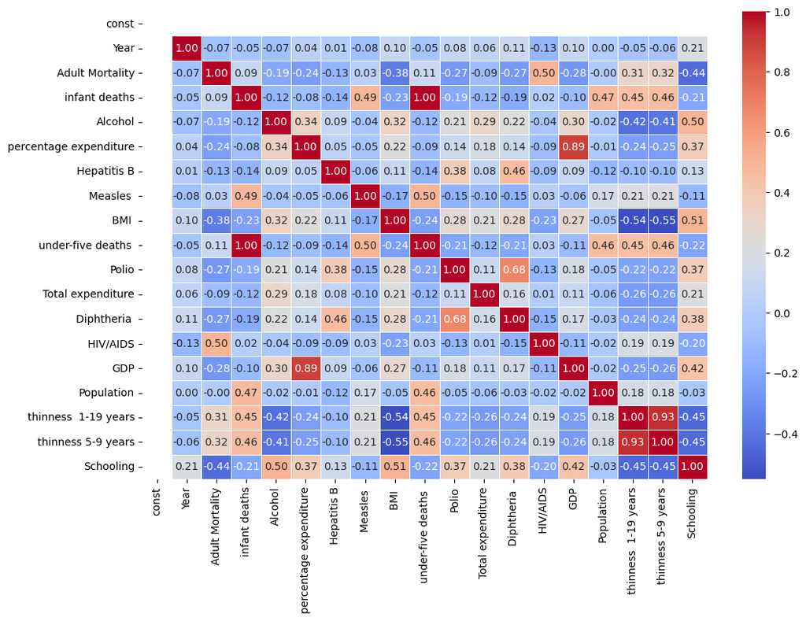

```python
# Calcular la matriz de correlación
corr_matrix = X_train.corr()

# Visualizarla
import seaborn as sns
import matplotlib.pyplot as plt
plt.figure(figsize=(12, 8))
sns.heatmap(corr_matrix, annot=True, cmap='coolwarm', fmt=".2f", linewidths=0.5)
plt.show()
```

```python
import pandas as pd

# Calcular la matriz de correlación
corr_matrix = X_train.corr()

# Crear un conjunto de columnas a eliminar debido a alta correlación
threshold = 0.9  # Umbral de correlación
columns_to_drop = []

for i in range(len(corr_matrix.columns)):
    for j in range(i):
        if abs(corr_matrix.iloc[i, j]) > threshold:
            colname = corr_matrix.columns[i]
            columns_to_drop.append(colname)

# Eliminar las columnas altamente correlacionadas
X_train_reduced = X_train.drop(columns=columns_to_drop)
print(f"Columnas eliminadas debido a alta correlación: {columns_to_drop}")
```

```
Columnas eliminadas debido a alta correlación: ['under-five deaths ', ' thinness 5-9 years']
```

Ahora aplicamos la selección hacia atrás para quedarnos con las variables más relevantes.

```python
import statsmodels.api as sm
from sklearn.model_selection import train_test_split
from sklearn.linear_model import LassoCV

# Dividir los datos en variables predictoras y variable objetivo
X = df.drop(columns=['Life expectancy '])  # Excluir variable objetivo y 'Status' (ya está eliminada)
y = df['Life expectancy ']

# Agregar una constante para el modelo
X = sm.add_constant(X)

# Dividir los datos en entrenamiento y prueba
X_train, X_test, y_train, y_test = train_test_split(X, y, test_size=0.3, random_state=42)

# Ajustar el modelo OLS (método de mínimos cuadrados ordinarios) para eliminación hacia atrás
def backward_elimination(X_train, y_train, significance_level=0.05):
    initial_model = sm.OLS(y_train, X_train).fit()
    while True:
        max_p_value = max(initial_model.pvalues)
        if max_p_value > significance_level:
            excluded_variable = initial_model.pvalues.idxmax()
            X_train = X_train.drop(columns=[excluded_variable])
            initial_model = sm.OLS(y_train, X_train).fit()
        else:
            break
    return initial_model, X_train

# Ejecutar eliminación hacia atrás
model, X_selected = backward_elimination(X_train, y_train)

# Ver los resultados de eliminación hacia atrás
print(f'Número de variables antes de eliminación: {X.shape[1]}')
print(f'Número de variables después de eliminación: {X_selected.shape[1]}')
print("Variables seleccionadas:")
print(X_selected.columns)

# Aplicar Lasso para regularización
lasso = LassoCV(cv=5, random_state=42)
lasso.fit(X_selected, y_train)

# Resultados de Lasso
print(f"Coeficientes de Lasso para las variables seleccionadas: {lasso.coef_}")
```

```
Número de variables antes de eliminación: 19
Número de variables después de eliminación: 14
Variables seleccionadas:
Index(['const', 'Adult Mortality', 'infant deaths', 'Alcohol', 'Hepatitis B',
       'Measles ', ' BMI ', 'under-five deaths ', 'Polio', 'Diphtheria ',
       ' HIV/AIDS', 'GDP', ' thinness  1-19 years', 'Schooling'],
      dtype='object')
Coeficientes de Lasso para las variables seleccionadas: [ 0.00000000e+00 -4.38831294e-02 -0.00000000e+00  0.00000000e+00
  0.00000000e+00 -8.03166103e-05  0.00000000e+00 -3.56044126e-03
  0.00000000e+00  1.30959256e-03 -0.00000000e+00  1.79500274e-04
 -0.00000000e+00  0.00000000e+00]
```

4. Generaremos un modelo de regresión lineal y al menos uno no lineal, para predecir la esperanza de vida. Imprimiremos en consola los coeficientes estimados al entrenar el modelo, e indicaremos para cuáles de ellos se puede puede afirmar que existe una asociación significativa con la respuesta, y el por qué de tu aseveración.

```
Regresión Lineal OLS:
                            OLS Regression Results
==============================================================================
Dep. Variable:       Life expectancy    R-squared:                       0.804
Model:                            OLS   Adj. R-squared:                  0.802
Method:                 Least Squares   F-statistic:                     642.6
Date:                Wed, 19 Feb 2025   Prob (F-statistic):               0.00
Time:                        13:04:12   Log-Likelihood:                -5865.2
No. Observations:                2056   AIC:                         1.176e+04
Df Residuals:                    2042   BIC:                         1.184e+04
Df Model:                          13
Covariance Type:            nonrobust
=========================================================================================
                            coef    std err          t      P>|t|      [0.025      0.975]
-----------------------------------------------------------------------------------------
const                    56.0020      0.674     83.147      0.000      54.681      57.323
Adult Mortality          -0.0212      0.001    -21.626      0.000      -0.023      -0.019
infant deaths             0.1075      0.011     10.143      0.000       0.087       0.128
Alcohol                   0.1370      0.029      4.668      0.000       0.079       0.195
Hepatitis B              -0.0171      0.005     -3.688      0.000      -0.026      -0.008
Measles               -2.944e-05   9.31e-06     -3.161      0.002   -4.77e-05   -1.12e-05
 BMI                      0.0446      0.006      7.391      0.000       0.033       0.056
under-five deaths        -0.0790      0.008    -10.149      0.000      -0.094      -0.064
Polio                     0.0239      0.006      4.271      0.000       0.013       0.035
Diphtheria                0.0426      0.006      7.339      0.000       0.031       0.054
 HIV/AIDS                -0.4803      0.021    -22.644      0.000      -0.522      -0.439
GDP                    6.702e-05   7.94e-06      8.443      0.000    5.15e-05    8.26e-05
 thinness  1-19 years    -0.0990      0.029     -3.386      0.001      -0.156      -0.042
Schooling                 0.9453      0.041     22.956      0.000       0.865       1.026
==============================================================================
Omnibus:                       76.710   Durbin-Watson:                   2.033
Prob(Omnibus):                  0.000   Jarque-Bera (JB):              169.792
Skew:                          -0.215   Prob(JB):                     1.35e-37
Kurtosis:                       4.340   Cond. No.                     1.06e+05
==============================================================================

Notes:
[1] Standard Errors assume that the covariance matrix of the errors is correctly specified.
[2] The condition number is large, 1.06e+05. This might indicate that there are
strong multicollinearity or other numerical problems.
R²: 0.8100395576182617
RMSE: 4.226407010224808

Random Forest:
Importancia de las características: [0.         0.25463599 0.00619107 0.0097019  0.00455965 0.00614403
 0.03455048 0.01043766 0.00697497 0.00811623 0.55241147 0.01041574
 0.02881714 0.06704367]
R²: 0.962563405326025
RMSE: 1.8762378831332418
```

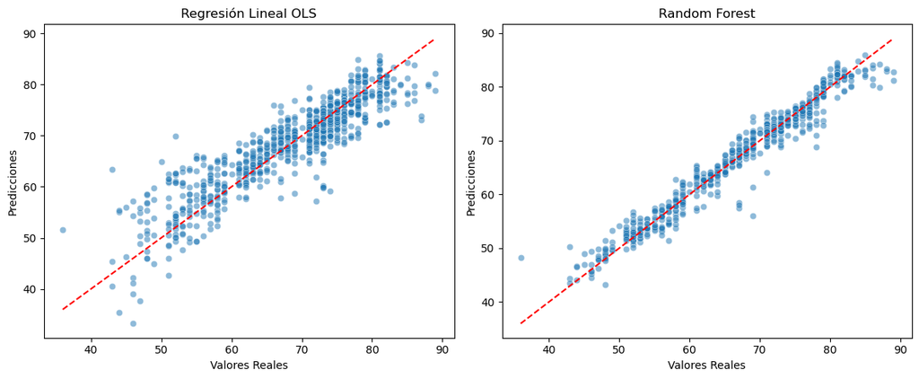

```python
import numpy as np
import statsmodels.api as sm
import matplotlib.pyplot as plt
import seaborn as sns
from sklearn.ensemble import RandomForestRegressor
from sklearn.metrics import mean_squared_error, r2_score
from sklearn.ensemble import RandomForestRegressor
from sklearn.metrics import mean_squared_error, r2_score
import matplotlib.pyplot as plt
import seaborn as sns

# -------------------- Regresión Lineal con OLS --------------------
# Entrenar el modelo con las variables seleccionadas por backward elimination
model_ols = sm.OLS(y_train, X_selected).fit()
y_pred_ols = model_ols.predict(X_test[X_selected.columns])

print("\nRegresión Lineal OLS:")
print(model_ols.summary())
print("R²:", r2_score(y_test, y_pred_ols))
print("RMSE:", np.sqrt(mean_squared_error(y_test, y_pred_ols)))

# -------------------- Modelo no lineal: Random Forest --------------------
rf = RandomForestRegressor(n_estimators=100, random_state=42)
rf.fit(X_selected, y_train)
y_pred_rf = rf.predict(X_test[X_selected.columns])

print("\nRandom Forest:")
print("Importancia de las características:", rf.feature_importances_)
print("R²:", r2_score(y_test, y_pred_rf))
print("RMSE:", np.sqrt(mean_squared_error(y_test, y_pred_rf)))

# -------------------- Gráficos de comparación --------------------
plt.figure(figsize=(12, 5))

# Gráfico de dispersión OLS
plt.subplot(1, 2, 1)
sns.scatterplot(x=y_test, y=y_pred_ols, alpha=0.5)
plt.plot([y_test.min(), y_test.max()], [y_test.min(), y_test.max()], 'r--')
plt.xlabel("Valores Reales")
plt.ylabel("Predicciones")
plt.title("Regresión Lineal OLS")

# Gráfico de dispersión Random Forest
plt.subplot(1, 2, 2)
sns.scatterplot(x=y_test, y=y_pred_rf, alpha=0.5)
plt.plot([y_test.min(), y_test.max()], [y_test.min(), y_test.max()], 'r--')
plt.xlabel("Valores Reales")
plt.ylabel("Predicciones")
plt.title("Random Forest")

plt.tight_layout()
plt.show()
```

Para estos dos modelos se utilizó la regresión lineal mediante OLS y la Random Forest, esto con la intencipon de encontrar el mejor ajuste. Primordialmente, el estadístico F nos indica que tenemos un modelo interesante que se puede analizar y tienen relevancia.